# Predicting Activities - Practical Machine Learning Assignment

Dr. Ali Sajid Imami

April 18, 2018

## Background

This document is a report generated as a partial requirement fulfillment for the [Coursera](https://coursera.org) course [Practical Machine Learning](https://www.coursera.org/learn/practical-machine-learning). This course is part of the Data Science Specialization by the prestigious [John’s Hopkins University’s Bloomberg School of Public Health](https://www.jhsph.edu/).

This report is generated in in R, utilizing the Rmd format for report’s markup and R language for all the relevant calculations. The report generation process was considerably eased by RStudio and the associated knitr package.

## Introduction

*Copied from the course assignment page*

Using devices such as Jawbone Up, Nike FuelBand, and Fitbit it is now possible to collect a large amount of data about personal activity relatively inexpensively. These type of devices are part of the quantified self movement – a group of enthusiasts who take measurements about themselves regularly to improve their health, to find patterns in their behavior, or because they are tech geeks.

One thing that people regularly do is quantify how much of a particular activity they do, but they rarely quantify how well they do it. In this project, your goal will be to use data from accelerometers on the belt, forearm, arm, and dumbell of 6 participants. They were asked to perform barbell lifts correctly and incorrectly in 5 different ways.

More information is available from the website here: [http://web.archive.org/web/20161224072740/http:/groupware.les.inf.puc-rio.br/har] (see the section on the Weight Lifting Exercise Dataset).

## Dataset

The data is provided as part of the project specification on Coursera’s project page. It consists of two sections: `pml-training.csv` and `pml-testing.csv`. The files are available as downloads on Coursera’s CDN and are also included in the `data` subdirectory in this repo.

```r
if (!dir.exists("data")) {
  dir.create("data")
}

if (!file.exists("data/pml-training.csv")) {
  download.file(url = "https://d396qusza40orc.cloudfront.net/predmachlearn/pml-training.csv", destfile = "data/pml-training.csv")
}

if (!file.exists("data/pml-testing.csv")) {
  download.file(url = "https://d396qusza40orc.cloudfront.net/predmachlearn/pml-testing.csv", destfile = "data/pml-testing.csv")
}
```

## Preparation and Data Inspection

We will now load the desired libraries and inspect the data for its features.

```r
library(tidyverse)
library(caret)
library(rattle)
library(corrplot)
library(rpart)
library(rpart.plot)
library(randomForest)
library(RColorBrewer)

set.seed(19900107)

col_spec <- cols(
  .default = col_double(),
  user_name = col_character(),
  cvtd_timestamp = col_character(),
  new_window = col_character(),
  classe = col_factor(levels = NULL)
)

total_training <- read_csv("data/pml-training.csv", na = c("NA","#DIV/0!",""), col_types = col_spec)

total_testing <- read_csv("data/pml-testing.csv", na = c("NA","#DIV/0!",""), col_types = col_spec)

in_training <- createDataPartition(total_training$classe, p = 0.75, list = FALSE)
training_set <- total_training[in_training, ]
testing_set <- total_training[-in_training, ]
```

From an initial inspection, the data seems to contain 160 variables with the training and testing datasets having 19622 and 20 observations respectively. An initial review also tells us that many variables are either NA or mostly NA. All of this can help us whittle down our feature set for only the important ones.

## Data Cleaning

To clean the data so only the necessary and valuable variables are retained, the following approach will be used:

1. All variables that are *mostly* NA (> 95%) will be removed as they would not add much information.
2. All variables that have Zero or Near-Zero Variance will be removed as they would not add much in the way of variance and consequently will not add much information.
3. All variables with identifying information and other metadata (timestamps etc.) will be removed as well.

The end result at this stage will be a data set that contains the variables contributing the maximum variance to the dataset and the outcome variable *classe*.

```r
NZVars <- nearZeroVar(total_training)
training_set <- testing_set[, -NZVars]
testing_set <- testing_set[, -NZVars]

AllNA    <- sapply(training_set, function(x) mean(is.na(x))) > 0.95
training_set <- training_set[, AllNA == FALSE]
testing_set <- testing_set[, AllNA == FALSE]

training_set <- training_set[, -(1:5)]
testing_set <- testing_set[, -(1:5)]
```

We can see that after the pruning of unnecessary features we are left with a manageable and informative 54 variables.

## Correlation Analysis

Before any modelling is done, a simple correlational analysis will highlight significant correlations and help us decide if we should go for a Principal Component Analysis before model building.

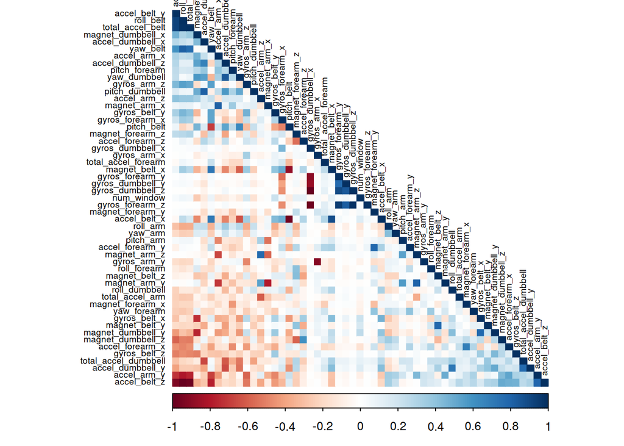

```r
correlation_matrix <- cor(training_set[, -54])

corrplot(correlation_matrix, order = "FPC", method = "color", type = "lower", tl.cex = 0.6, tl.col = "black")
```

We can see quite a few highly correlated variables in the matrix above (signified by the darker color). However, the number of correlations is still not large enough that we go for PCA. We will proceed with the analysis as-is.

## Model Building

The methods used will be:

1. Decision Trees
2. Generalized Boosted Models
3. Random Forests

Each model is followed by a confusion matrix to better visualize the accuracy.

```r
jBuPuFun <- colorRampPalette(brewer.pal(n = 9, "BuPu"))
paletteSize <- 256
jBuPuPalette <- jBuPuFun(paletteSize)

plot_confusion_matrix <- function(confusion_matrix) {
  confusion_df <- as_tibble(confusion_matrix$table)
  p <- ggplot(data = confusion_df, aes(x = Prediction, y = Reference, fill = n))
  p + theme(axis.text.x = element_text(angle = 90, hjust = 1, vjust = 0.5)) +
    geom_tile() +
    labs(x = "Predicted Class", y = "Actual Class") +
    scale_fill_gradient2(
        low = jBuPuPalette[1],
        mid = jBuPuPalette[paletteSize/2],
        high = jBuPuPalette[paletteSize],
        midpoint = (max(confusion_df$n) + min(confusion_df$n)) / 2,
        name = "") +
    theme(legend.key.height = unit(2, "cm"))
}
```

### Decision Trees

Decision trees might be a good idea in this case as we have a lot of variables with numeric values. We do not expect accuracy to be too high but still *good enough*.

```r
set.seed(19900107)

mod_dt <- train(classe ~ ., method = "rpart", data = training_set)

mod_dt$finalModel
```

```
## n= 4904
##
## node), split, n, loss, yval, (yprob)
##       * denotes terminal node
##
##  1) root 4904 3509 A (0.28 0.19 0.17 0.16 0.18)
##    2) roll_belt< 129.5 4479 3101 A (0.31 0.21 0.19 0.18 0.11)
##      4) pitch_forearm< -32.75 410    2 A (1 0.0049 0 0 0) *
##      5) pitch_forearm>=-32.75 4069 3099 A (0.24 0.23 0.21 0.2 0.12)
##       10) num_window>=45.5 3871 2901 A (0.25 0.24 0.22 0.2 0.087)
##         20) num_window< 241.5 879  404 A (0.54 0.14 0.1 0.17 0.043) *
##         21) num_window>=241.5 2992 2168 B (0.17 0.28 0.26 0.2 0.1)
##           42) magnet_dumbbell_z< -19.5 885  505 A (0.43 0.36 0.056 0.14 0.012)
##             84) num_window< 686.5 434  110 A (0.75 0.18 0.0046 0.067 0.0069) *
##             85) num_window>=686.5 451  206 B (0.12 0.54 0.11 0.21 0.018) *
##           43) magnet_dumbbell_z>=-19.5 2107 1394 C (0.055 0.24 0.34 0.23 0.14)
##             86) magnet_dumbbell_x>=-442.5 623  333 B (0.04 0.47 0.061 0.19 0.24) *
##             87) magnet_dumbbell_x< -442.5 1484  809 C (0.061 0.14 0.45 0.25 0.091) *
##       11) num_window< 45.5 198   41 E (0 0 0 0.21 0.79) *
##    3) roll_belt>=129.5 425   17 E (0.04 0 0 0 0.96) *
```

[figure not shown]

```r
fancyRpartPlot(mod_dt$finalModel)
```

Next we do prediction on our testing dataset.

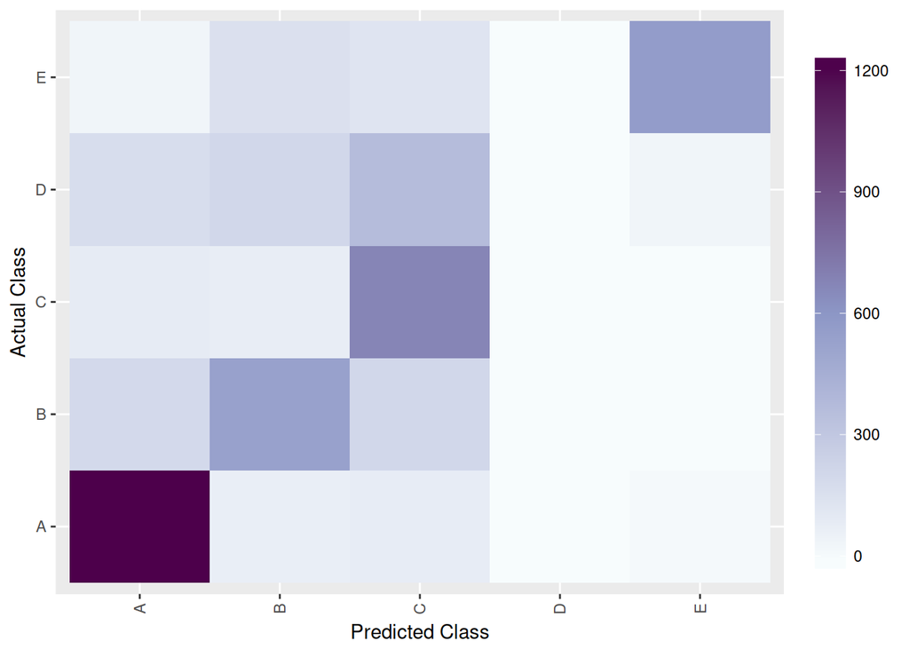

```r
predicted_dt <- predict(mod_dt, newdata = testing_set)

confmat_dt <- confusionMatrix(predicted_dt, testing_set$classe)

plot_confusion_matrix(confmat_dt)
```

It is evident from the Confusion Matrix plot that this model is not very well performing. In fact, the accuracy of this model is 0.608075 which is not really good at all.

### Generalized Boosted Models

Genearlized Boosted Models might be a good idea in this case as we have a lot of variables with numeric values. We expect accuracy to be high.

```r
set.seed(19900107)

control_gbm <- trainControl(method = "repeatedcv", number = 5, repeats = 1)
mod_gbm  <- train(classe ~ ., data=training_set, method = "gbm",
                    trControl = control_gbm, verbose = FALSE)
mod_gbm$finalModel
```

```
## A gradient boosted model with multinomial loss function.
## 150 iterations were performed.
## There were 53 predictors of which 45 had non-zero influence.
```

Next we do prediction on our testing dataset.

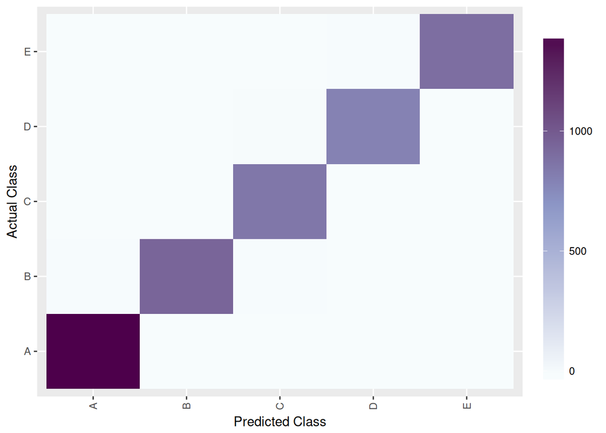

```r
predicted_gbm <- predict(mod_gbm, newdata = testing_set)

confmat_gbm <- confusionMatrix(predicted_gbm, testing_set$classe)

plot_confusion_matrix(confmat_gbm)
```

The Confusion Matrix plot from the Generalized Boosted Model is almost completely correct. It appears to have a very high accuracy and in fact the accuracy of this model is 0.9944943 which is near perfect.

### Random Forests

Random Forests play well with a reasonable number of observations and variables and might be a good strategy here.

```r
set.seed(19900107)

control_rf <- trainControl(method="cv", number=3, verboseIter=FALSE)
mod_rf  <- train(classe ~ ., data=training_set, method = "rf",
                    trControl = control_rf)
mod_rf$finalModel
```

```
##
## Call:
##  randomForest(x = x, y = y, mtry = param$mtry)
##                Type of random forest: classification
##                      Number of trees: 500
## No. of variables tried at each split: 53
##
##         OOB estimate of  error rate: 1.22%
## Confusion matrix:
##      A   B   C   D   E class.error
## A 1393   1   0   0   1 0.001433692
## B    9 930   9   1   0 0.020021075
## C    0  11 839   5   0 0.018713450
## D    0   1   9 794   0 0.012437811
## E    1   5   1   6 888 0.014428413
```

Next we do prediction on our testing dataset.

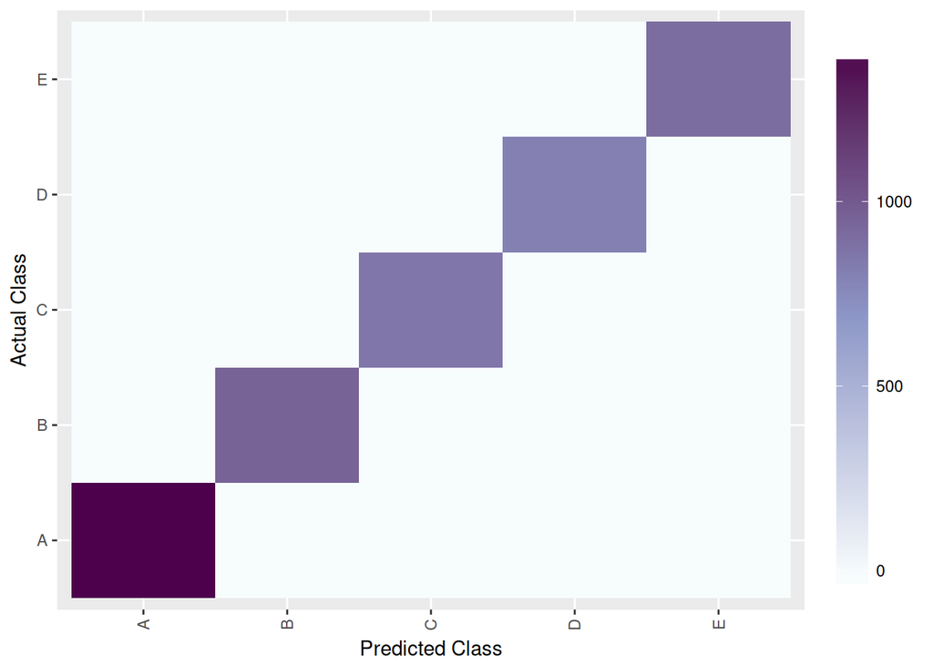

```r
predicted_rf <- predict(mod_rf, newdata = testing_set)

confmat_rf <- confusionMatrix(predicted_rf, testing_set$classe)

plot_confusion_matrix(confmat_rf)
```

### Final Decision

Final results of accuracy are as follows:

Decision Trees:0.608075 Generalized Boosted Model:0.9944943 Random Forest:1

## Predicting the Test Data

We will now apply our selected model, i.e. Random Forest model to the testing data set and see how well it fares.

```r
final_prediction <- predict(mod_rf, newdata = total_testing)
final_prediction
```

```
##  [1] B A B A A E D B A A B C B A E E A B B B
## Levels: A B C D E
```